# Анализ рынка недвижимости в Москве: Графическая оценка

Здравствуйте! Мы, Александра и Сергей, рады представить вам графический анализ данных о рынке недвижимости в Москве. В этом отчете вы найдете ряд визуализаций, которые помогут лучше понять распределение ключевых характеристик квартир. Мы включили графики и агрегированную информацию, чтобы сделать данные более наглядными и доступными для принятия решений. Надеемся, что наш анализ будет полезен для вашей работы!

1. На круговой диаграмме представлено распределение типов парковки в жилых домах Москвы. График визуализирует доли различных вариантов парковки, таких как подземная, наземная и другие, что позволяет легко оценить преобладающие решения по организации парковочных мест в столице.

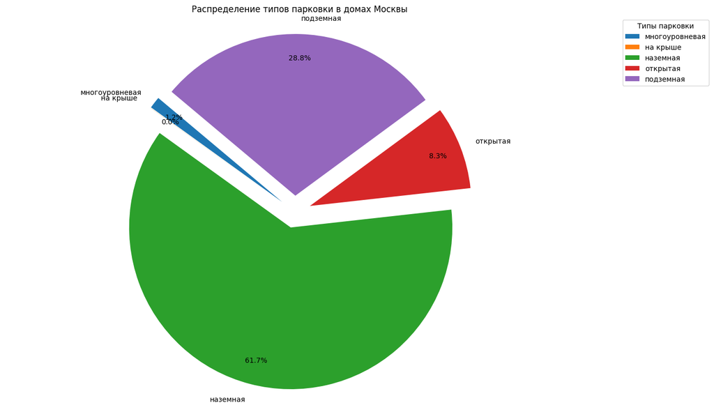

```python
dfp = df.groupby('Parking').size().reset_index(name='Count')
plt.figure(figsize=(15, 10))
explode = [0.1] * len(dfp)  # Выделяем все секции
plt.pie(dfp['Count'], labels=dfp['Parking'], autopct='%1.1f%%', startangle=140,
        explode=explode, textprops={'fontsize': 10}, pctdistance=0.85)

# Добавление легенды
plt.legend(dfp['Parking'], title="Типы парковки", loc="upper right", bbox_to_anchor=(1.2, 1))

# Заголовок
plt.title('Распределение типов парковки в домах Москвы')
plt.axis('equal');
```

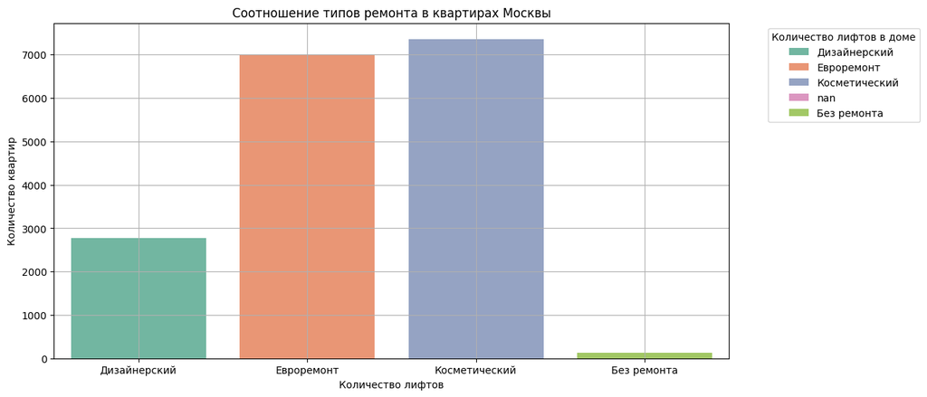

```python
plt.figure(figsize=(12, 6))
sns.countplot(x='Apartment_renovation', data=df, hue=df['Apartment_renovation'].astype(str), palette='Set2')
plt.title('Соотношение типов ремонта в квартирах Москвы')
plt.xlabel('Количество лифтов')
plt.ylabel('Количество квартир')
plt.legend(title='Количество лифтов в доме', bbox_to_anchor=(1.05, 1), loc='upper left')
plt.grid(True)
```

3. На гистограмме представлено распределение видов из окон квартир. График демонстрирует категории 'Во двор', 'На улицу' и 'На улицу и двор'. Эта информация позволяет визуально оценить популярность различных видов и их влияние на предпочтения жильцов.

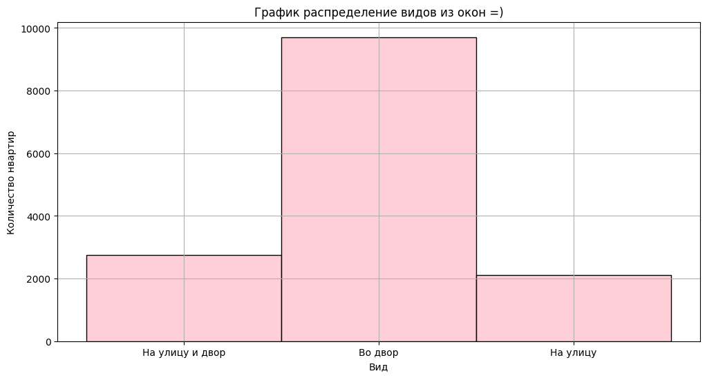

```python
plt.figure(figsize=(12, 6))
sns.histplot(df['Windows'], bins=6, kde=False, color="pink")
plt.title('График распределение видов из окон =)')
plt.xlabel('Вид')
plt.ylabel('Количество нвартир')
plt.grid(True)
```

4. На столбчатой диаграмме представлено соотношение количества комнат в квартирах Москвы. График позволяет визуально оценить распределение квартир по количеству комнат, таких как однокомнатные, двухкомнатные, трехкомнатные и более. Эта информация помогает понять предпочтения жильцов и тенденции на рынке недвижимости.

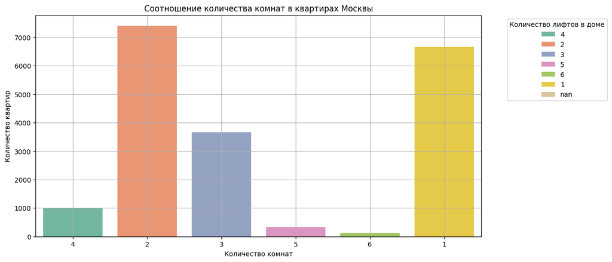

```python
plt.figure(figsize=(12, 6))
sns.countplot(x='Quantity_of_rooms', data=df, hue=df['Quantity_of_rooms'].astype(str), palette='Set2')
plt.title('Соотношение количества комнат в квартирах Москвы')
plt.xlabel('Количество комнат')
plt.ylabel('Количество квартир')
plt.legend(title='Количество лифтов в доме', bbox_to_anchor=(1.05, 1), loc='upper left')
plt.grid(True)
```

5. На гистограмме представлено распределение расстояний квартир от ближайшей станции метро. График позволяет визуально оценить, сколько квартир расположено на различных расстояниях от метро, что помогает понять доступность жилья для жителей города и их предпочтения при выборе места проживания.

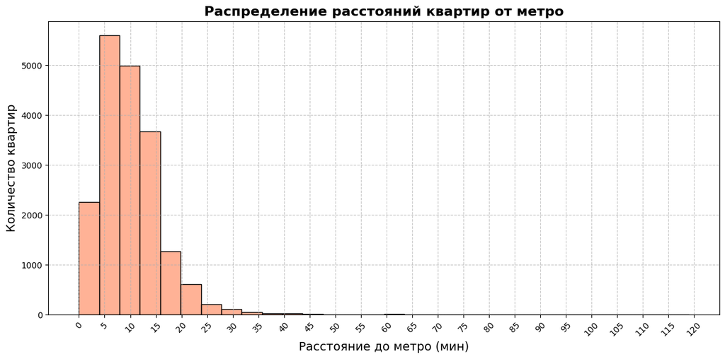

```python
plt.figure(figsize=(12, 6))

sns.histplot(df['Distance_min'], kde=False, bins=30, color='coral', edgecolor='black', alpha=0.6)


plt.title('Распределение расстояний квартир от метро', fontsize=16, fontweight='bold')
plt.xlabel('Расстояние до метро (мин)', fontsize=14)
plt.ylabel('Количество квартир', fontsize=14)
max_distance = int(df['Distance_min'].max()) + 5
plt.xticks(ticks=np.arange(0, max_distance, 5), fontsize=10, rotation=45)

plt.grid(True, linestyle='--', alpha=0.7)

plt.tight_layout()
```

6. На графике в виде ящика с усами представлено распределение площадей квартир в Москве. Этот график позволяет визуально оценить диапазон площадей, медиану, а также выявить выбросы. Он помогает понять, какие размеры квартир наиболее распространены и как они варьируются в пределах города.

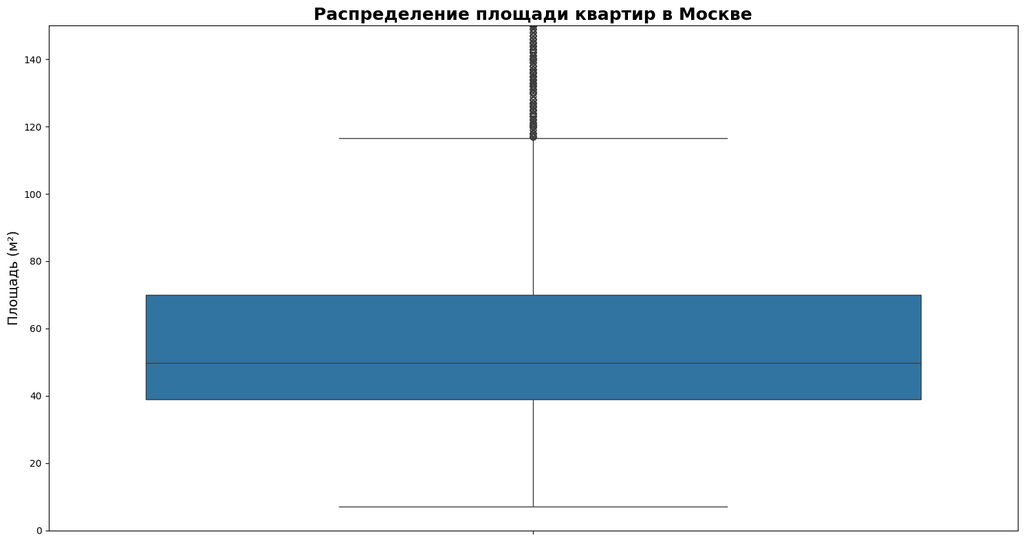

```python
plt.figure(figsize=(15, 8))

sns.boxplot(y='Area_sm', data=df)

plt.xticks(rotation=90)


plt.title('Распределение площади квартир в Москве', fontsize=18, fontweight='bold')
plt.ylabel('Площадь (м²)', fontsize=14)

plt.ylim(0, 150)

plt.tight_layout()
```

7. На гистограмме представлено распределение цен на квартиры. График позволяет визуально оценить, как цены варьируются в различных диапазонах, выявляя наиболее распространенные ценовые категории. Это помогает понять рыночные тенденции и предпочтения покупателей в сегменте недвижимости."

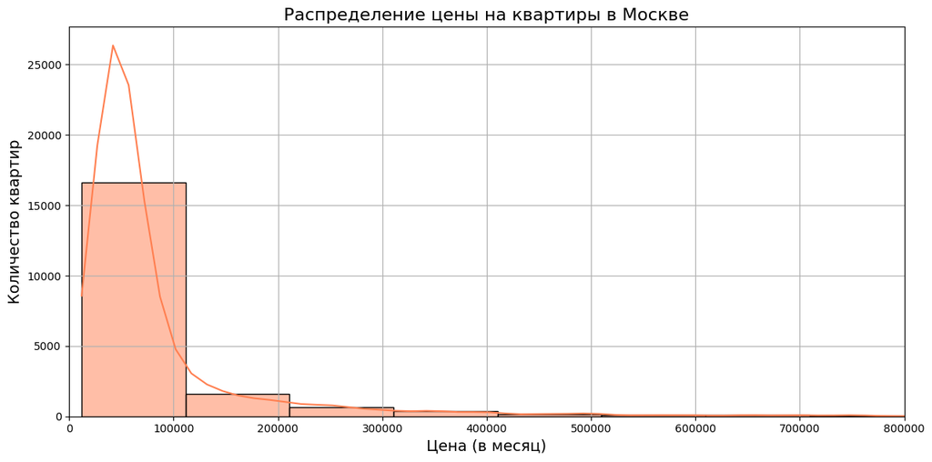

```python
df['Cost_per_month'] = pd.to_numeric(df['Cost_per_month'], errors='coerce')

plt.figure(figsize=(12, 6))

# Построение гистограммы с KDE
sns.histplot(df['Cost_per_month'].dropna(), bins=30, color='coral', kde=True)

# Заголовок и подписи
plt.title('Распределение цены на квартиры в Москве', fontsize=16)
plt.xlabel('Цена (в месяц)', fontsize=14)
plt.ylabel('Количество квартир', fontsize=14)

# Ограничение оси X
plt.xlim(0, 0.8e6)  # Ограничение по иксу на 1.5 миллиона

# Настройка сетки
plt.grid(True)
plt.tight_layout()
```

8. На барплоте представлено распределение квартир по признаку включения коммунальных платежей в стоимость. График позволяет визуально оценить, сколько квартир имеют коммунальные платежи, включенные в аренду, и сколько — нет. Это помогает понять предпочтения жильцов и особенности рынка аренды.

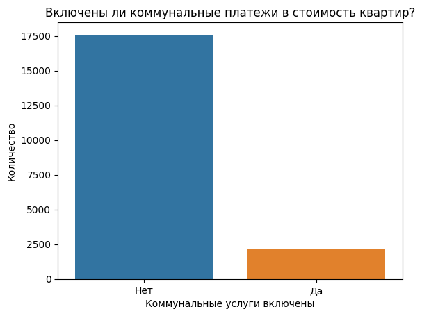

```python
sns.countplot(x='Is_included_utility_charges', data=df, hue='Is_included_utility_charges', legend=False)

plt.title('Включены ли коммунальные платежи в стоимость квартир?')
plt.xlabel('Коммунальные услуги включены')
plt.ylabel('Количество')

plt.xticks(ticks=[0, 1], labels=['Нет', 'Да']);
```

9. В этом графике представлено распределение сроков аренды квартир. Мы анализируем, как различные сроки аренды, такие как краткосрочные и долгосрочные, выбираются жильцами. Этот график помогает выявить предпочтения арендаторов и понять рыночные тенденции в сфере аренды жилья.

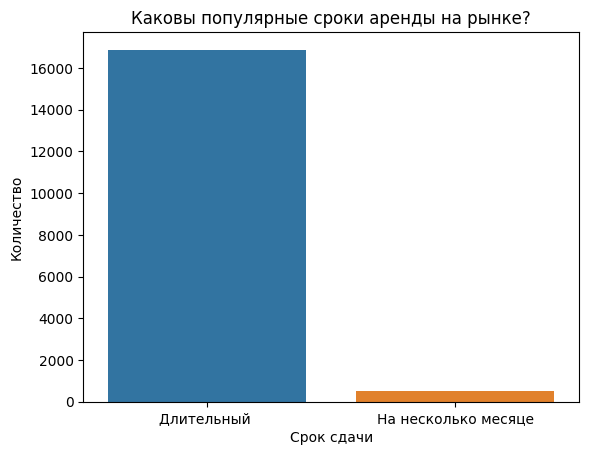

```python
sns.countplot(x='Lease_term', data=df, hue='Lease_term', legend=False)

plt.title('Каковы популярные сроки аренды на рынке?')
plt.xlabel('Срок сдачи')
plt.ylabel('Количество')

plt.xticks(ticks=[0, 1], labels=['Длительный ', 'На несколько месяце']);
```

10. На графике представлено распределение количества лифтов в подъездах Москвы. Мы анализируем, сколько подъездов имеют один, два или более лифтов, что позволяет оценить уровень комфортности и доступности жилья. Этот график помогает понять, как количество лифтов может влиять на предпочтения жильцов и стоимость квартир.

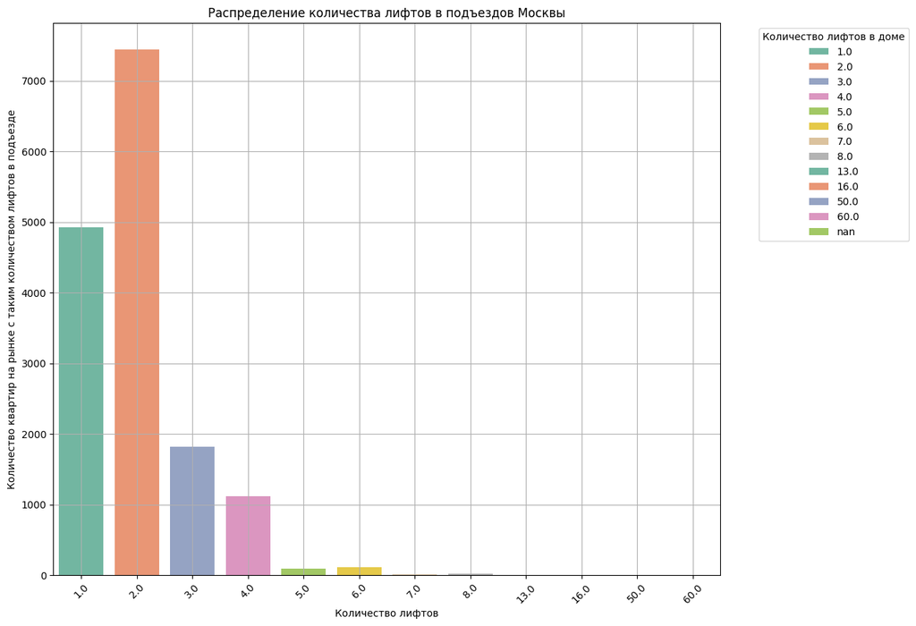

```python
plt.figure(figsize=(12, 10))
sns.countplot(x='Elevator_total', data=df, hue=df['Elevator_total'].astype(str), palette='Set2')
plt.title('Распределение количества лифтов в подъездов Москвы')
plt.xlabel('Количество лифтов')
plt.ylabel('Количество квартир на рынке с таким количеством лифтов в подъезде')
plt.xticks(rotation=45)
plt.legend(title='Количество лифтов в доме', bbox_to_anchor=(1.05, 1), loc='upper left')
plt.grid(True)
```

11. На графике представлено распределение возражений арендодателей на проживание с детьми в квартирах. Анализируем, сколько арендодателей согласны или не согласны на аренду жилья семьям с детьми. Этот график позволяет выявить тенденции и предпочтения на рынке аренды, а также понять, как эти возражения могут влиять на выбор жилья семьями.

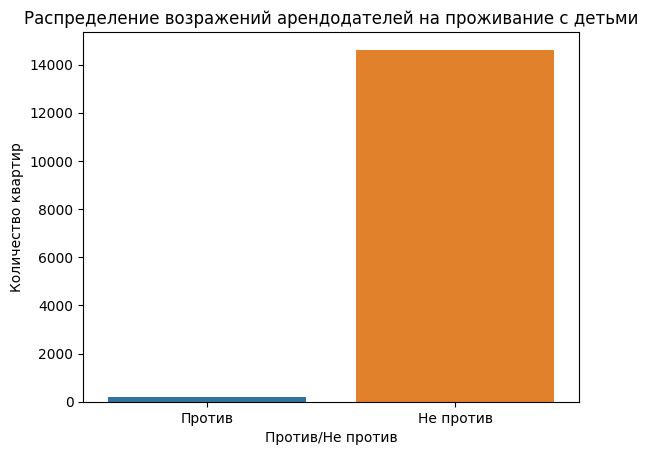

```python
sns.countplot(x='With_children', data=df, hue='With_children', legend=False)

plt.title('Распределение возражений арендодателей на проживание с детьми')
plt.xlabel('Против/Не против')
plt.ylabel('Количество квартир')

plt.xticks(ticks=[0, 1], labels=['Против', 'Не против']);
```

12. На графике представлено распределение возражений арендодателей на проживание с животными в квартирах. Мы анализируем, сколько арендодателей допускают или отказывают аренду жильцам с домашними питомцами. Этот график помогает выявить рыночные тенденции и предпочтения арендаторов, а также понять, как наличие животных может влиять на условия аренды.

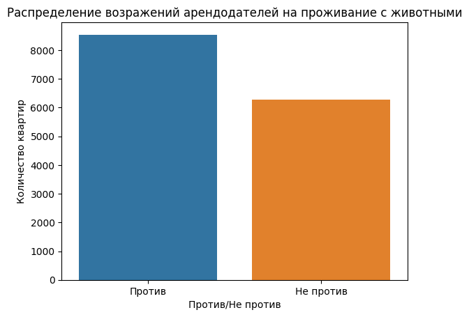

```python
sns.countplot(x='With_pets', data=df, hue='With_pets', legend=False)

plt.title('Распределение возражений арендодателей на проживание с животными')
plt.xlabel('Против/Не против')
plt.ylabel('Количество квартир')

plt.xticks(ticks=[0, 1], labels=['Против', 'Не против']);
```

13. На графике представлено распределение количества уборных в квартирах. Мы анализируем, как варьируется количество уборных в разных квартирах, что позволяет оценить уровень удобства и комфортности жилья. Этот график помогает понять предпочтения жильцов и особенности рынка недвижимости в зависимости от количества санитарных узлов.

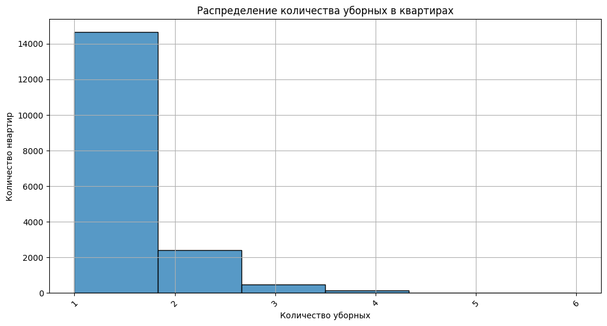

```python
plt.figure(figsize=(12, 6))
sns.histplot(df['WashingRoom_total'], bins=6, kde=False)
plt.title('Распределение количества уборных в квартирах')
plt.xlabel('Количество уборных')
plt.ylabel('Количество нвартир')
plt.xticks(rotation=45)
plt.grid(True)
```

14. На графике представлено распределение количества балконов в квартирах Москвы. Мы анализируем, как варьируется количество балконов в разных квартирах, что позволяет оценить уровень удобства и привлекательности жилья. Этот график помогает выявить тенденции на рынке недвижимости и предпочтения жильцов относительно дополнительных пространств.

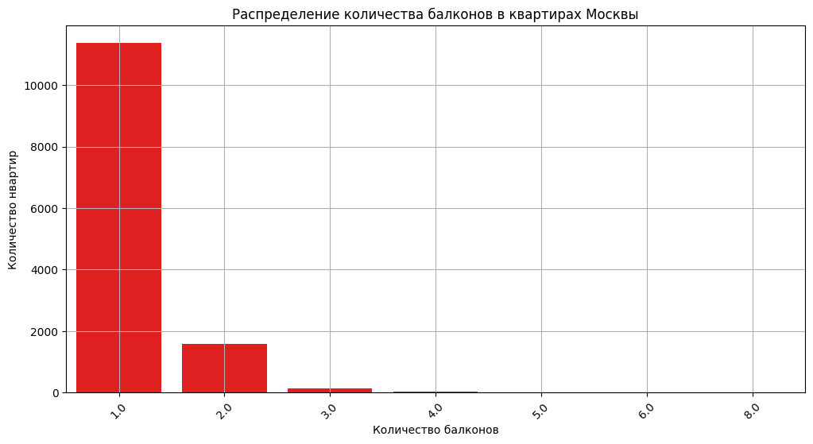

```python
plt.figure(figsize=(12, 6))
sns.countplot(x='Loggia_and_Balcony', data=df, color='red')
plt.title('Распределение количества балконов в квартирах Москвы')
plt.xlabel('Количество балконов')
plt.ylabel('Количество нвартир')
plt.xticks(rotation=45)
plt.grid(True)
```